# 휴젤 (145020) 기업 분석 보고서

Alpha Hunter Hidden Gem Week 19 — 글로벌 보톡스 3강, 미국 직판 본격화

Author

Alpha Hunter × Chimera AI

Published

May 5, 2026

# 기업 개요

| 항목 | 내용 |
| --- | --- |
| **종목명** | 휴젤 (145020.KQ) |
| **업종** | 바이오/미용의료 (보툴리눔 톡신, 필러) |
| **핵심 제품** | 레티보(Letybo) — 보톡스, 더채움(The Chaeum) — 필러 |
| **시총** | 약 2.8조원 |
| **현재가** | 261,500원 |
| **Forward PER** | 15.4x |
| **EV/EBITDA** | 10.6x |
| **컨센서스** | Strong Buy (14명 애널리스트) |
| **목표가** | 300,000 ~ 430,000원 (평균 357,714원) |

**핵심 투자 포인트**

## 0.1 사업 요약

휴젤은 **한국 최초이자 글로벌 3번째로 미국·중국·유럽 3대 시장 모두에서 보톡스 허가를 획득한 기업**이다.

- **레티보(Letybo)**: 2024년 3월 미국 FDA 승인. 중국·유럽 이미 진출
- **더채움 필러**: HA 필러 라인업 확대 중
- **미국 직판**: 2026년 하반기 자체 영업조직 가동 → 유통마진 직접 수취
- **생산 CAPA**: 신공장 가동으로 기존 대비 3배 확대

## 0.2 투자 논리 (Bull Case)

1. **미국 시장 폭발 성장**: 2026년 북남미 수출 1,011억원 전망 (YoY +67%)
2. **가격 경쟁력**: AbbVie 보톡스 대비 20~30% 저렴, 품질 동등
3. **직판 전환**: 유통마진 수취로 영업이익률 추가 상승 기대
4. **글로벌 보톡스 시장**: 연평균 11.7% 성장 (2030년 $66.8B)
5. **밸류에이션 매력**: Forward PER 15.4x는 성장률 대비 현저히 저평가

# 1 실적 분석

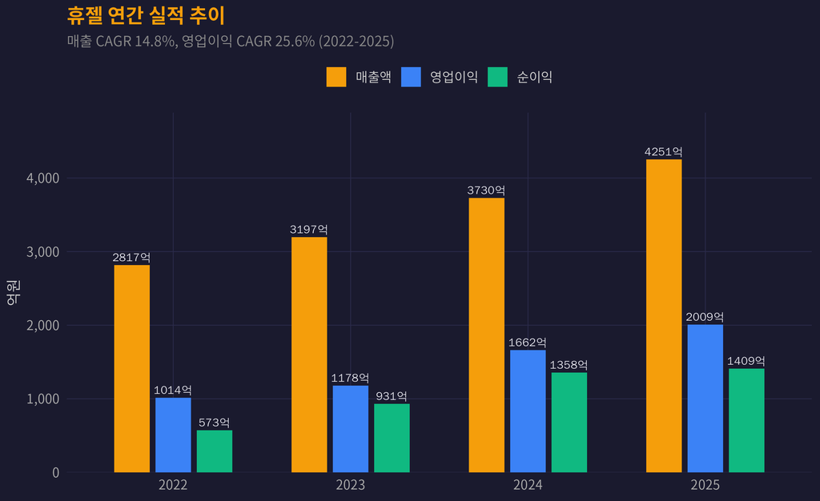

Figure 1: 휴젤 연간 실적 추이 (2022~2025)

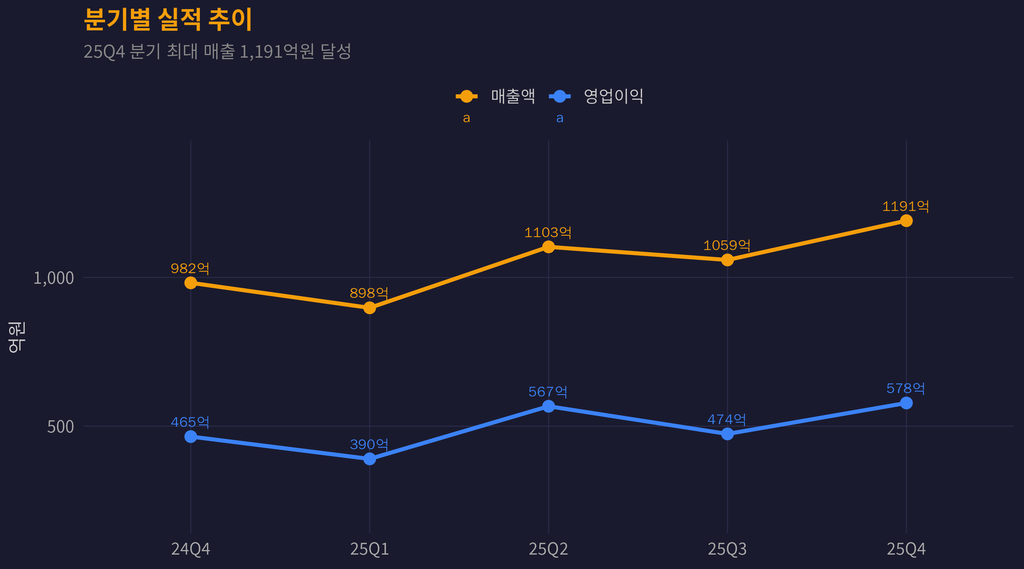

Figure 2: 분기별 매출 및 영업이익 추이

# 2 주가 분석

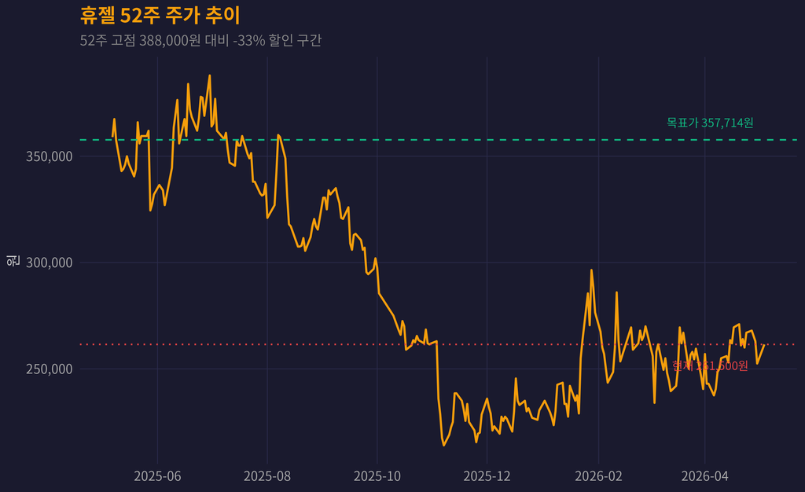

Figure 3: 휴젤 52주 주가 추이

# 3 밸류에이션 비교

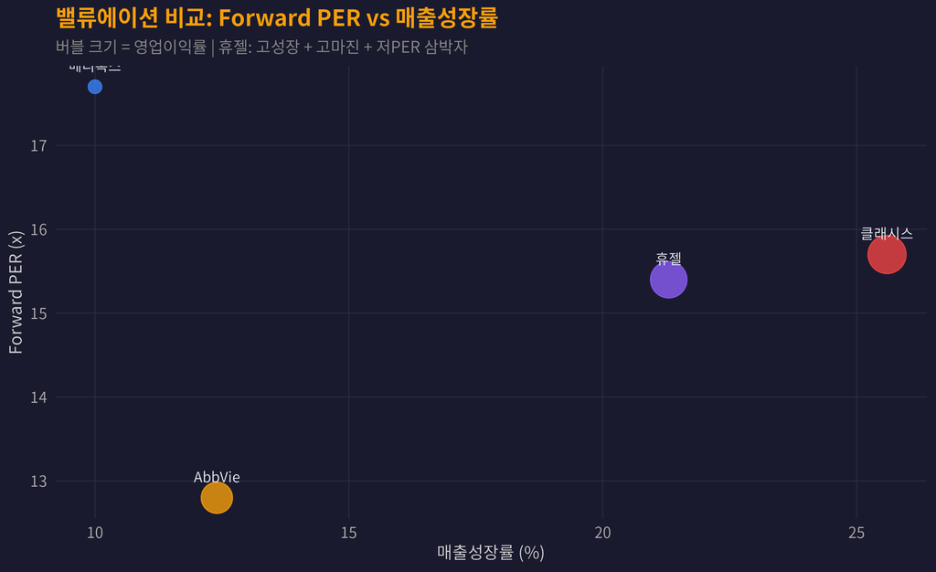

Figure 4: 동종업종 밸류에이션 비교

# 4 해자(Moat) 분석

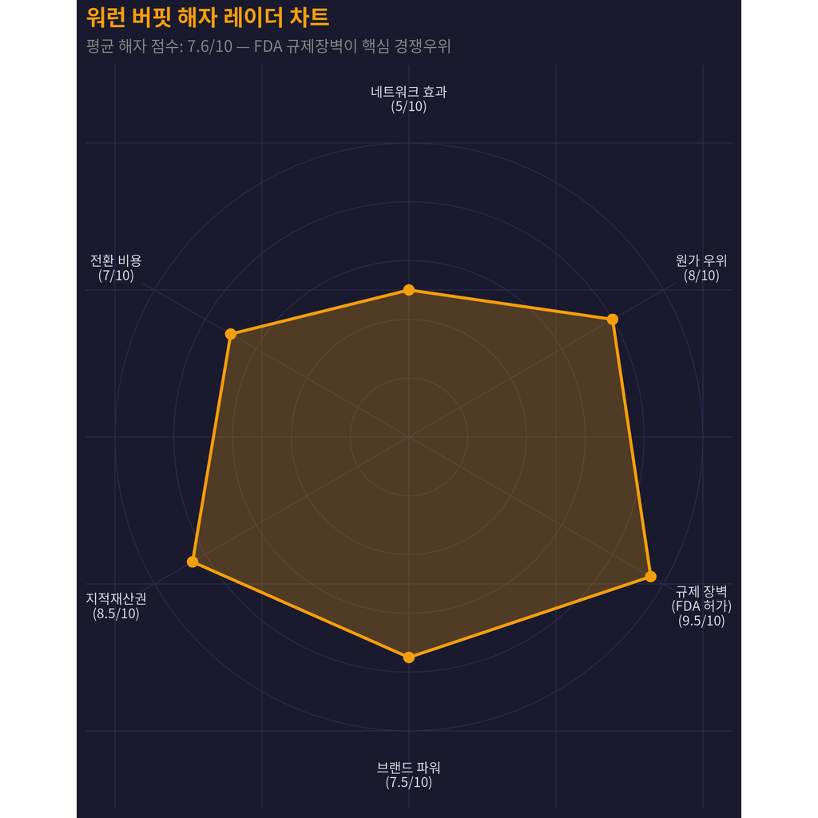

Figure 5: 워런 버핏 해자 레이더 차트

**해자 분석 요약**

- **규제 장벽 (9.5/10)**: 미국 FDA + 중국 NMPA + 유럽 CE 동시 보유. 한국 기업 유일. 허가 취득까지 5~10년 소요
- **지적재산권 (8.5/10)**: 보툴리눔 톡신 제조 핵심 특허, 균주 원천기술 보유
- **원가 우위 (8.0/10)**: AbbVie 보톡스 대비 20~30% 저렴한 가격에 동등 품질
- **브랜드 파워 (7.5/10)**: 중국·유럽에서 이미 프리미엄 브랜드 포지셔닝 완료
- **전환 비용 (7.0/10)**: 시술자 숙련도, 용량 체계 학습에 시간 필요

# 5 피터 린치 스토리 점수

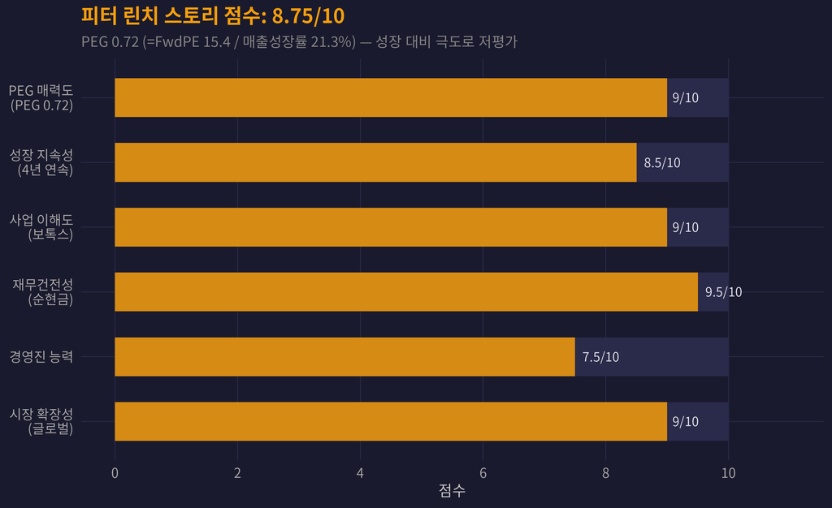

Figure 6: 피터 린치 스토리 점수

# 6 리스크 분석

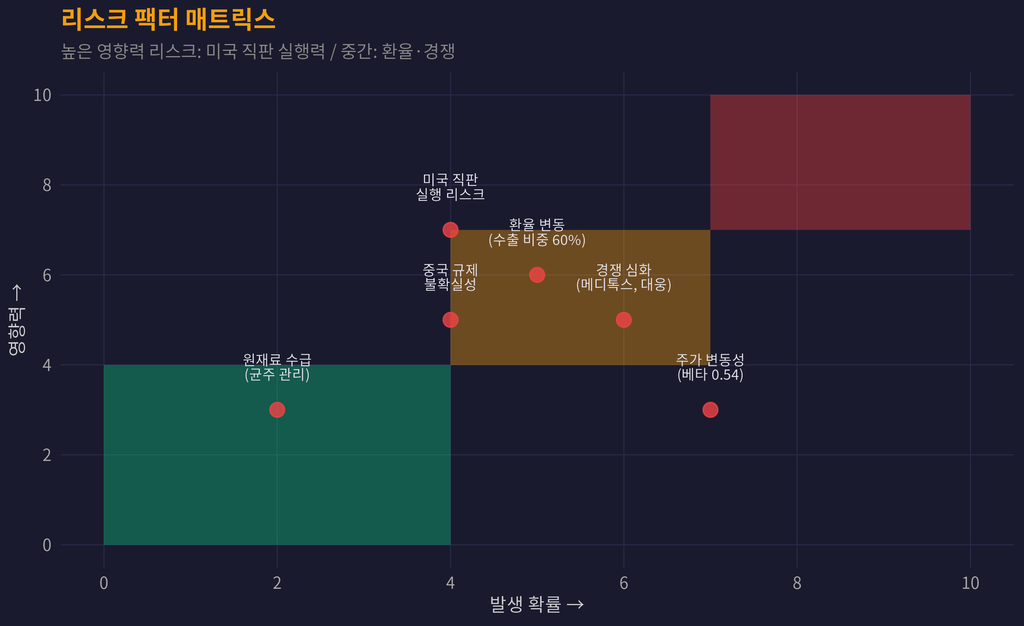

Figure 7: 리스크 팩터 대시보드

**주요 리스크**

1. **미국 직판 실행 리스크**: 2026년 하반기 자체 영업조직 가동. 아직 초기 단계로 실적 가시화까지 2~3분기 소요 예상
2. **환율 변동**: 수출 비중 60%+. 원화 강세 시 실적 하방 압력
3. **경쟁 심화**: 메디톡스 회복세, 대웅제약 나보타 미국 진출 추진

# 7 매수 시나리오

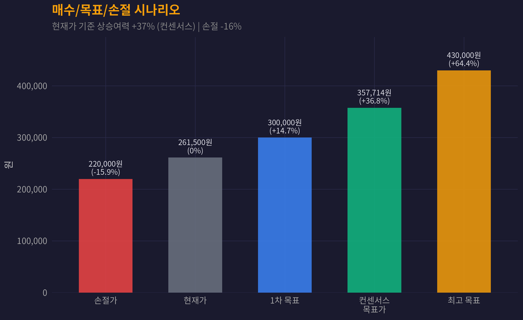

Figure 8: 목표가/매수가/손절가 시나리오

# 8 투자 전략 요약

## 8.1 매수 전략

[output not shown]

## 8.2 카탈리스트 타임라인

1. **2026년 Q2**: 미국 직판 조직 구축 완료 발표 예상
2. **2026년 하반기**: 미국 자체 영업 본격 가동 → 마진 개선
3. **2026년 연간**: 북남미 수출 1,011억원 (YoY +67%) 달성 여부
4. **2027년**: 미국 매출 비중 20%+ 돌파 시 밸류 리레이팅

**면책 조항**

이 프로젝트는 가상 투자 시뮬레이션 목적으로 작성되었습니다. 실제 투자 권유가 아닙니다.